# Gathering insights about COVID19 Worldwide Testing using Linear Mixed Models

UWF IDC6940 Capstone Project on Linear Mixed Models (LMMs)

Alex Ottley and Autumn Clark (Advisor: Dr. Cohen)

2025-04-22

## Understanding Linear Mixed Models (LMMs)

Linear Mixed Models (LMMs) are statistical models that extend traditional linear regression by including both:

- **Fixed effects:** These are the overall effects you’re interested in studying (e.g., how testing volume affects case counts across all countries).
- **Random effects:** These account for variation within subgroups or clusters (e.g., differences between countries), allowing intercepts and/or slopes to vary by group.

## Understanding Linear Mixed Models (LMMs) cont.

LMMs are especially useful when:

- Data is **hierarchical** or **nested** (like days within countries),
- Measurements are repeated over time,
- The data is **unbalanced** (not the same number of observations for each group).

## Software Packages used for LMMs

```r
# loading packages
library(tidyverse)
library(knitr)
library(ggthemes)
library(ggrepel)
library(dslabs)
library(lme4)
library(nlme)
library(dplyr)
library(ggplot2)
library(readr)
```

## Methods - Model Structure and Notation

The general form of a linear mixed model is:
$$y_{ij} = \beta_0 + \beta_1 x_{ij} + b_{0j} + b_{1j}x_{ij} + \varepsilon_{ij}$$
Where,

- $y_{ij}$: response variable for observation in $i$ in group $j$
- $x_{ij}$: predictor (e.g., scaled daily tests)
- $\beta_0,\beta_1$: fixed intercept and slope (population-level)
- $b_{0j}, b_{1j}$: random intercept and slope for group $j$ (e.g., country)
- $\varepsilon_{ij}$: residual error, assumed to be normally distributed: $\varepsilon_{ij} \sim N (0, \sigma^2)$

## Methods - Model Structure and Notation continued

In matrix form, the LMM can be represented as:

$$y = X\beta + Zb + \varepsilon$$
Where,

- $y$: vector of outcomes
- $X$: fixed-effects design matrix
- $\beta$: vector of fixed effect coefficients
- $Z$: random-effects design matrix
- $b$: vector of random effects, assumed $\sim N (0, G)$
- $\varepsilon$: residual errors, assumed $\sim N(0, R)$

## Assumptions

1. **Linearity** - the relationship between predictor (fixed effects) and response variable are linear.
2. **Independence of Residual Errors** - residual errors of a model are assumed to be independent within each level of the random effect structure
3. **Normality of Residual Errors and Random Effects** - Residual errors and random effects are assumed to be **normally distributed**.
4. **Homoscedasticity**, the variance of the residuals, should be **constant** across all levels of the independent variables.

## Data Overview

- Our data comes from a [Covid19 Worldwide Testing](https://www.kaggle.com/datasets/lin0li/covid19testing/data) dataset on Kaggle. It includes daily test counts, daily positive cases, and other variables across different countries over time.

```r
# Load Data
library(readr)
COVID19 <- read_csv("tested_worldwide.csv")
kable(head(COVID19))
```

| Date | Country_Region | Province_State | positive | active | hospitalized | hospitalizedCurr | recovered | death | total_tested | daily_tested | daily_positive |
| --- | --- | --- | --- | --- | --- | --- | --- | --- | --- | --- | --- |
| 2020-01-16 | Iceland | All States | 3 | NA | NA | NA | NA | NA | NA | NA | NA |
| 2020-01-17 | Iceland | All States | 4 | NA | NA | NA | NA | NA | NA | NA | 1 |
| 2020-01-18 | Iceland | All States | 7 | NA | NA | NA | NA | NA | NA | NA | 3 |
| 2020-01-20 | South Korea | All States | 1 | NA | NA | NA | NA | NA | 4 | NA | NA |
| 2020-01-22 | United States | All States | 0 | NA | NA | NA | NA | 0 | 0 | NA | NA |
| 2020-01-22 | United States | Massachusetts | 0 | NA | NA | NA | NA | 0 | 0 | NA | NA |

```r
df <- COVID19
```

## Why Linear Mixed Models (LMMs)?

- Linear mixed models were chosen due to their ability to model nested data, adjust for within-group correlation, and incorporate individual variation in trends.
- These models also handle unbalanced data (i.e., unequal/unbalanced observations per country) and missingness better than traditional methods like repeated-measures ANOVA or fixed-effects OLS regression.

## Application to COVID-19 Data

- A study was conducted to employ linear mixed models to examine the relationship between the number of daily COVID-19 positive cases reported across various countries over time.The data set consists of repeated daily observations for each country, which results in multilevel structure where each country is considered a separate group with its own data points over time. This hierarchical structure gives the opportunity to account for both the overall trends in the data and the variability across different countries.
- The model was designed to account for both the fixed effects of the number of daily tests conducted, which can influence case detection, and the random effects that capture country-specific deviations in testing practices and positivity rates. The model allows the both the intercept, baseline positivity, and the slope, the effect of testing on reported cases, to vary by country.

## Key components of the model

- Response variable: **daily_positive** — the number of newly confirmed cases per day
- Fixed effect predictor: **daily_tested_scaled** — the number of daily tests conducted (scaled by 1,000)
- Random effects: Intercept and slope for each **Country_Region**, allowing both baseline positivity and test effectiveness to vary by country

The model formula in R was specified as: **lmer(daily_positive ~ daily_tested_scaled + (daily_tested_scaled | Country_Region), data = df_clean)**

## Exploratory Data Analysis

- Before modeling, we cleaned the data by removing rows with missing values in the daily test count, daily positive cases, and region columns.
- We also scaled the test count variable by dividing it by 1,000 for easier interpretation.

```r
df <- COVID19
#Convert Date to Date format
df$Date <- as.Date(df$Date)

#Remove rows with missing values in relevant columns
df_clean <- df %>%
  filter(!is.na(daily_positive), !is.na(daily_tested), !is.na(Country_Region))

#Rescale daily_tested column to improve interpretation and convergence
df_clean$daily_tested_scaled <- df_clean$daily_tested / 1000
```

## Modeling

```r
#Fit LMM with random intercept and slope
model_refined <- lmer(daily_positive ~ daily_tested_scaled + (daily_tested_scaled | Country_Region), data = df_clean)
```

**Key components of the model**

- Response variable: **daily_positive** — the number of newly confirmed cases per day
- Fixed effect predictor: **daily_tested_scaled** — the number of daily tests conducted (scaled by 1,000)
- Random effects: Intercept and slope for each **Country_Region**

The model formula in R was specified as: **lmer(daily_positive ~ daily_tested_scaled + (daily_tested_scaled | Country_Region), data = df_clean)**

- This model allows each country to have its own baseline number of positive cases and its own relationship between testing volume and positivity.

## Fixed Effects Interpretation

```r
#Extract and print key fixed effects
fixef(model_refined) #estimates for population-level intercept and slope
```

```
        (Intercept) daily_tested_scaled
           95.05436            52.16033
```

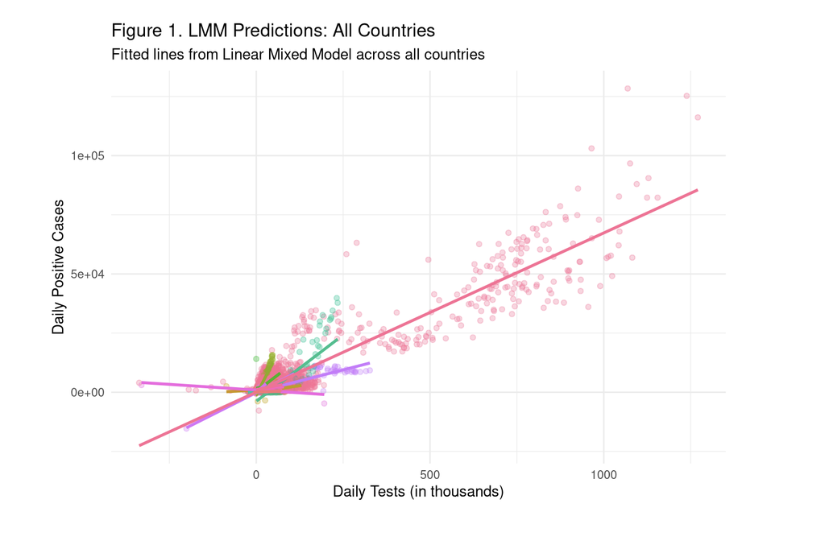

## Random Effects Interpretation

```r
VarCorr(model_refined)
```

```
 Groups         Name                Std.Dev. Corr
 Country_Region (Intercept)          659.941
                daily_tested_scaled   64.935 -0.423
 Residual                           1725.488
```

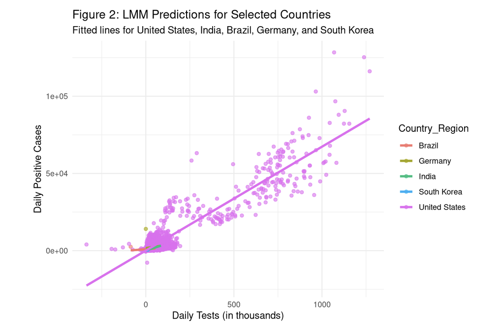

## Conclusion

- Linear mixed models are powerful tools for analyzing complex, time-based public health data, capturing both global trends and country-specific differences.
- This project helped us understand global COVID-19 testing patterns, showing that the number of tests is a strong predictor of detected cases, but the effect size varies by country.
- It also shows the value of LMMs over simpler models, like linear regression, when working with complex, international health data.

## References

Bates, Douglas et al. 2005. “Fitting Linear Mixed Models in r.” *R News* 5 (1): 27–30.